# London Bike Rentals and London weather

2021-09-30

```r
knitr::opts_chunk$set(
  message = FALSE,
  warning = FALSE,
  tidy=FALSE,     # display code as typed
  size="small")   # slightly smaller font for code
options(digits = 3)

# default figure size
knitr::opts_chunk$set(
  fig.width=6.75,
  fig.height=6.75,
  fig.align = "center"
)
```

[output not shown]

Having imported the datafame, we need to inspect it to see what kind of variables it contains, whether there are any missing values, etc.

```r
skimr::skim(bike_weather)
```

Data summary

| Name | bike_weather |
| --- | --- |
| Number of rows | 3959 |
| Number of columns | 25 |
| _______________________ |  |
| Column type frequency: |  |
| character | 1 |
| factor | 2 |
| numeric | 21 |
| POSIXct | 1 |
| ________________________ |  |
| Group variables | None |

**Variable type: character**

| skim_variable | n_missing | complete_rate | min | max | empty | n_unique | whitespace |
| --- | --- | --- | --- | --- | --- | --- | --- |
| prcp_attributes | 2 | 1 | 1 | 1 | 0 | 5 | 0 |

**Variable type: factor**

| skim_variable | n_missing | complete_rate | ordered | n_unique | top_counts |
| --- | --- | --- | --- | --- | --- |
| month | 0 | 1 | TRUE | 12 | Jan: 341, Mar: 341, May: 341, Aug: 341 |
| weekday | 0 | 1 | TRUE | 7 | Sun: 566, Mon: 566, Fri: 566, Sat: 566 |

**Variable type: numeric**

| skim_variable | n_missing | complete_rate | mean | sd | p0 | p25 | p50 | p75 | p100 | hist |
| --- | --- | --- | --- | --- | --- | --- | --- | --- | --- | --- |
| bikes_hired | 0 | 1.00 | 25887.76 | 9564.84 | 2764.0 | 18985.00 | 25730.0 | 32711.5 | 73094.0 | ▃▇▅▁▁ |
| yday | 2 | 1.00 | 183.24 | 106.20 | 1.0 | 91.00 | 183.0 | 276.0 | 366.0 | ▇▇▇▇▇ |
| temp | 2 | 1.00 | 11.60 | 5.49 | -4.1 | 7.50 | 11.4 | 15.8 | 28.6 | ▁▆▇▅▁ |
| dewp | 2 | 1.00 | 7.11 | 4.68 | -9.2 | 3.80 | 7.3 | 10.7 | 18.8 | ▁▃▇▇▂ |
| slp | 3136 | 0.21 | 1015.56 | 9.78 | 978.2 | 1009.85 | 1015.7 | 1021.8 | 1041.4 | ▁▂▇▇▂ |
| stp | 3137 | 0.21 | 106.20 | 285.69 | 0.1 | 9.22 | 14.6 | 22.0 | 999.7 | ▇▁▁▁▁ |
| visib | 27 | 0.99 | 10.88 | 3.16 | 0.3 | 9.70 | 10.5 | 11.4 | 27.7 | ▁▇▃▁▁ |
| wdsp | 2 | 1.00 | 4.07 | 1.70 | 0.8 | 2.80 | 3.8 | 5.0 | 12.2 | ▅▇▃▁▁ |
| mxspd | 2 | 1.00 | 6.86 | 2.52 | 1.5 | 5.10 | 6.7 | 8.2 | 21.0 | ▅▇▂▁▁ |
| gust | 2633 | 0.33 | 13.21 | 3.31 | 7.2 | 10.80 | 12.4 | 14.9 | 28.3 | ▆▇▃▁▁ |
| max_temp | 2 | 1.00 | 15.72 | 6.49 | -1.2 | 11.00 | 15.2 | 20.5 | 37.2 | ▂▇▇▃▁ |
| min_temp | 2 | 1.00 | 7.52 | 5.09 | -9.4 | 3.90 | 7.7 | 11.7 | 21.7 | ▁▅▇▆▁ |
| prcp | 2 | 1.00 | 1.67 | 3.68 | 0.0 | 0.00 | 0.0 | 1.5 | 48.0 | ▇▁▁▁▁ |
| i_fog | 2 | 1.00 | 0.68 | 0.47 | 0.0 | 0.00 | 1.0 | 1.0 | 1.0 | ▃▁▁▁▇ |
| i_rain_drizzle | 2 | 1.00 | 0.06 | 0.24 | 0.0 | 0.00 | 0.0 | 0.0 | 1.0 | ▇▁▁▁▁ |
| i_snow_ice | 7 | 1.00 | 0.00 | 0.06 | 0.0 | 0.00 | 0.0 | 0.0 | 1.0 | ▇▁▁▁▁ |
| i_hail | 7 | 1.00 | 0.02 | 0.13 | 0.0 | 0.00 | 0.0 | 0.0 | 1.0 | ▇▁▁▁▁ |
| i_thunder | 12 | 1.00 | 0.00 | 0.03 | 0.0 | 0.00 | 0.0 | 0.0 | 1.0 | ▇▁▁▁▁ |
| ea | 2 | 1.00 | 1.05 | 0.33 | 0.3 | 0.80 | 1.0 | 1.3 | 2.2 | ▂▇▆▂▁ |
| es | 2 | 1.00 | 1.44 | 0.52 | 0.5 | 1.00 | 1.3 | 1.8 | 3.9 | ▆▇▃▁▁ |
| rh | 2 | 1.00 | 75.08 | 11.87 | 34.1 | 66.50 | 76.5 | 84.2 | 100.0 | ▁▂▆▇▃ |

**Variable type: POSIXct**

| skim_variable | n_missing | complete_rate | min | max | median | n_unique |
| --- | --- | --- | --- | --- | --- | --- |
| day | 0 | 1 | 2010-07-30 | 2021-05-31 | 2015-12-30 | 3959 |

## Aesthetic mappings

In this first task, we will discuss a core concept of ggplot, the mapping of data values onto aesthetics. We will be using the R package **tidyverse**, which includes `ggplot()` and other related functions.

In the most basic use of ggplot, we call the `ggplot()` function with a dataset and an aesthetic mapping (created with `aes()`), and then we add a `geom`etry, such as `geom_line()` to draw lines or `geom_point()` to draw points.

Try this for yourself. Map the column `day` onto the x axis and the column `temp` onto the y axis, and use `geom_line()` to display the data.

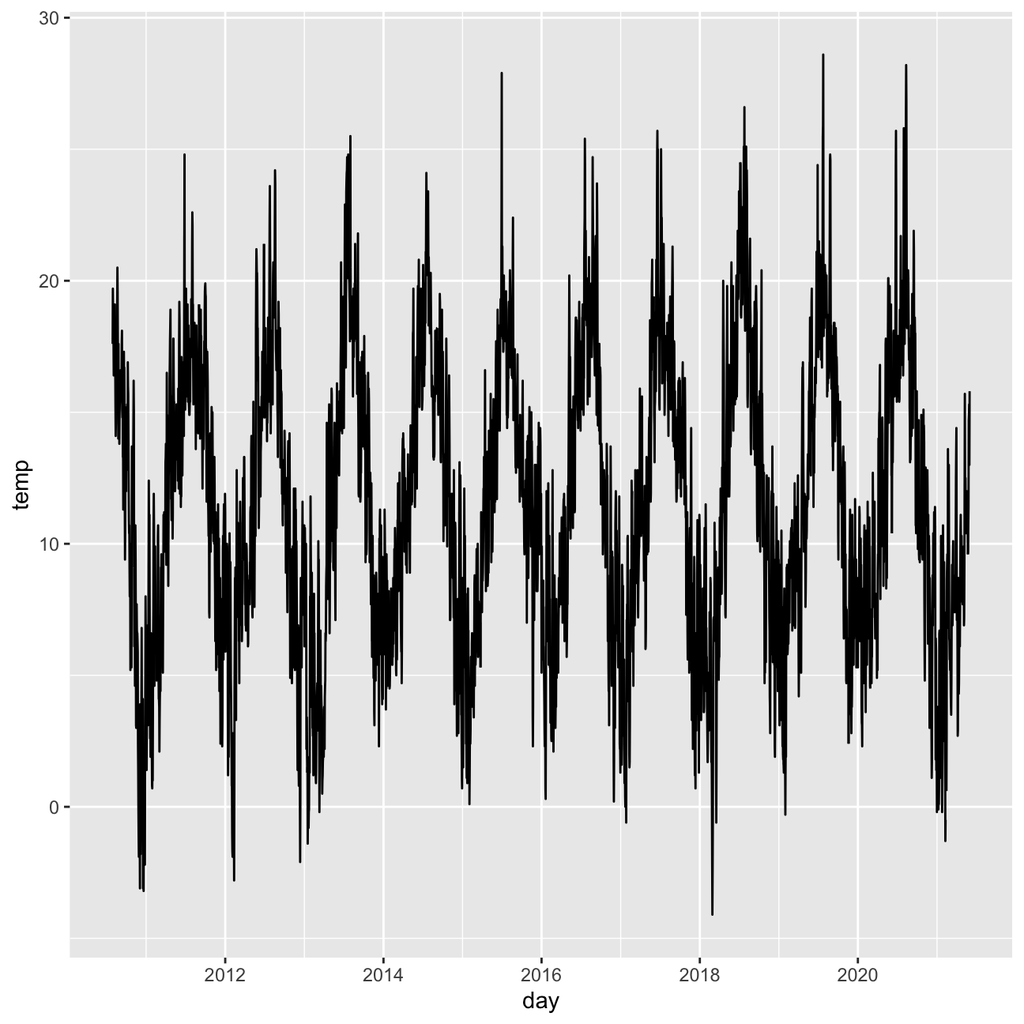

```r
ggplot(bike_weather, aes(x = day, y = temp)) +
  geom_line()
```

Try again, using `geom_point()` instead of `geom_line()`.

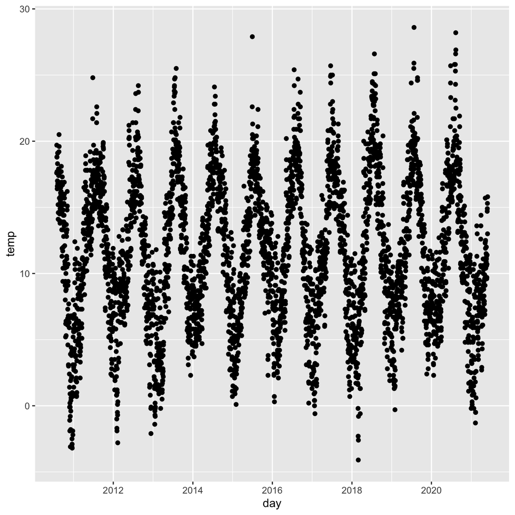

```r
ggplot(bike_weather, aes(x = day, y = temp)) +
  geom_point()
```

And now swap which column you map to x and which to y.

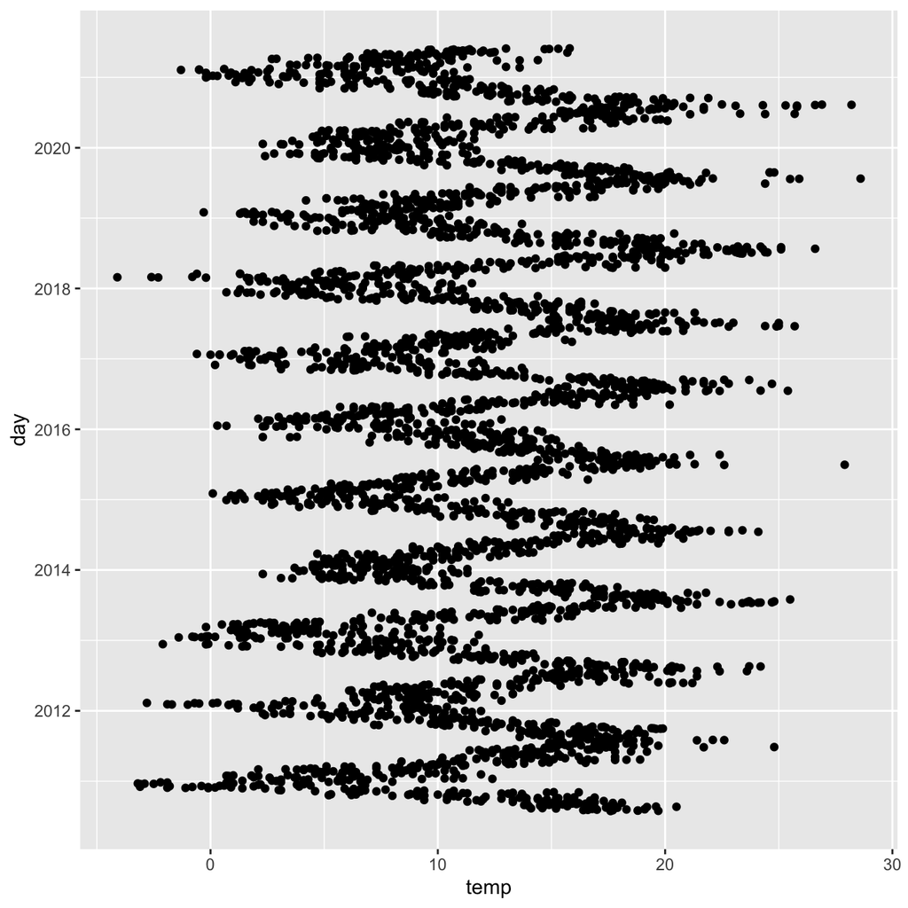

```r
ggplot(bike_weather, aes(x = temp, y = day)) +
  geom_point()
```

## Ploting distributions of `temp`

You can use other geoms to make different types of plots. For example, `geom_histogram` will make a histogram and `geom_boxplot()` will make boxplots.

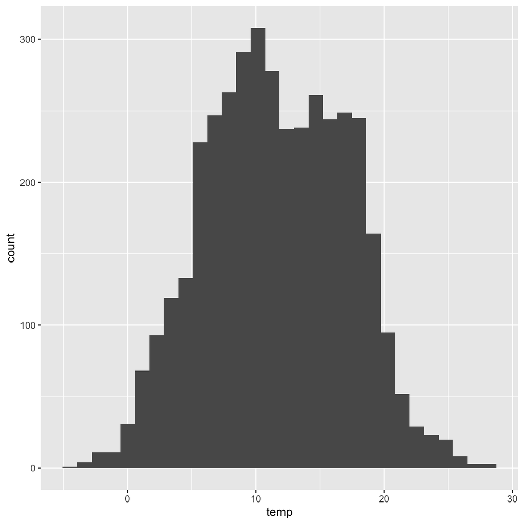

```r
ggplot(bike_weather, aes(x = temp)) +
  geom_histogram()
```

For boxplots, we frequently want categorical data on the x or y axis. For example, we might want a separate boxplot for each month. Try this out. Put `month` on the x axis, `temp` on the y axis, and use `geom_boxplot()`.

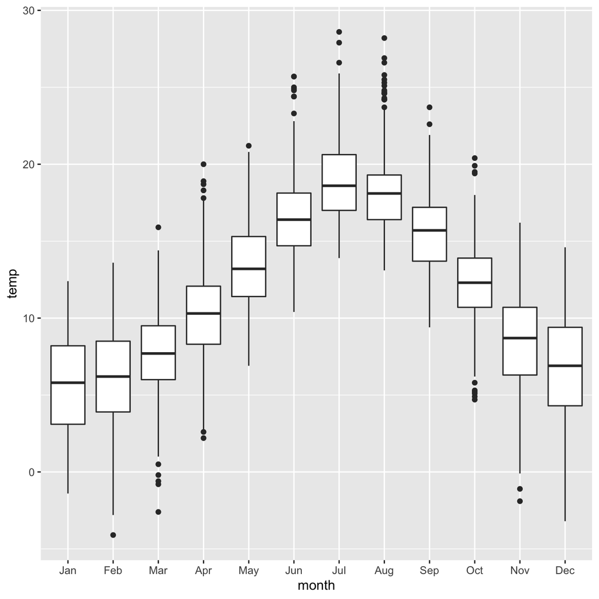

```r
ggplot(bike_weather, aes(x = month, y = temp)) +
  geom_boxplot()
```

## Adding colour

Make a scatter plot of `temp` against `day`, using the `colour` aesthetic to colour points by month.

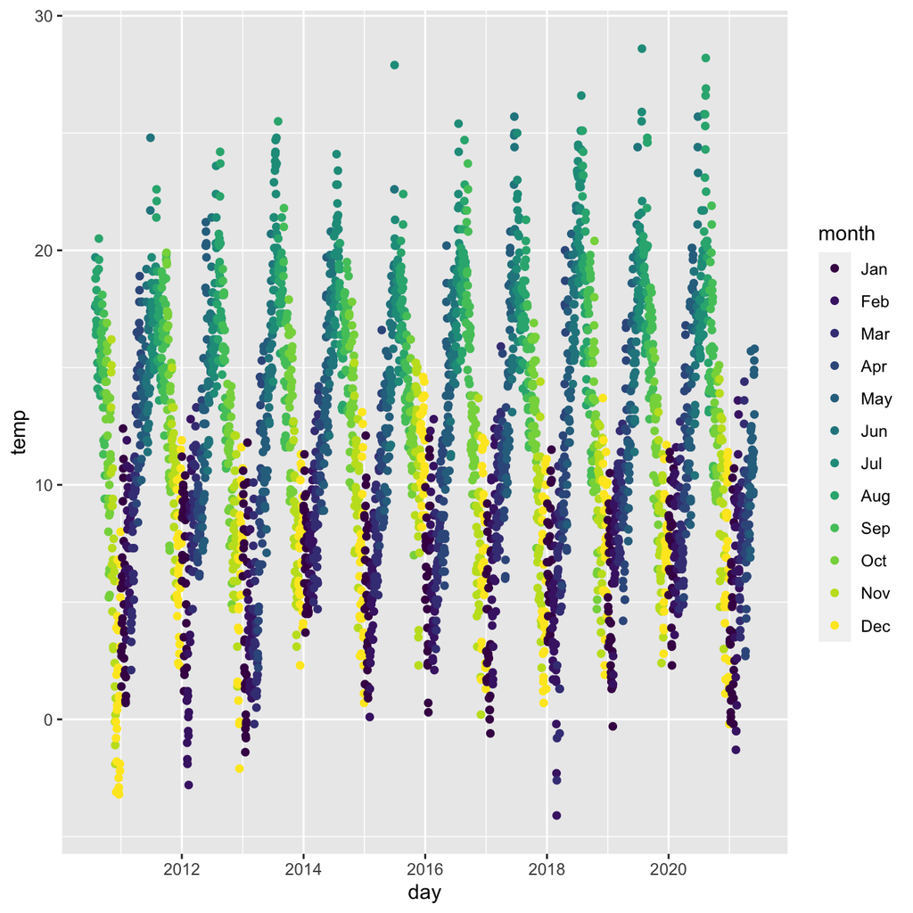

```r
ggplot(bike_weather, aes(x = day, y = temp, colour=month)) +
  geom_point()
```

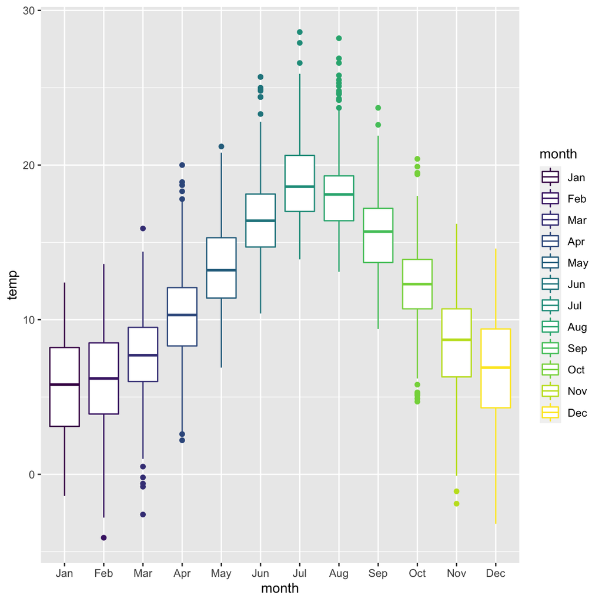

```r
ggplot(bike_weather, aes(x = month, y = temp, colour=month)) +
  geom_boxplot()
```